# Homework 4

## Question 6

No multiple comparisons are need because each of Codeine and Acunpuncture has only two options to it, so we know that the difference between those two options for each variable must be significant. We also expect there to be a difference in Pain Tolerance groups already, that is why we blocked them so we don’t do multiple comparisons there either.

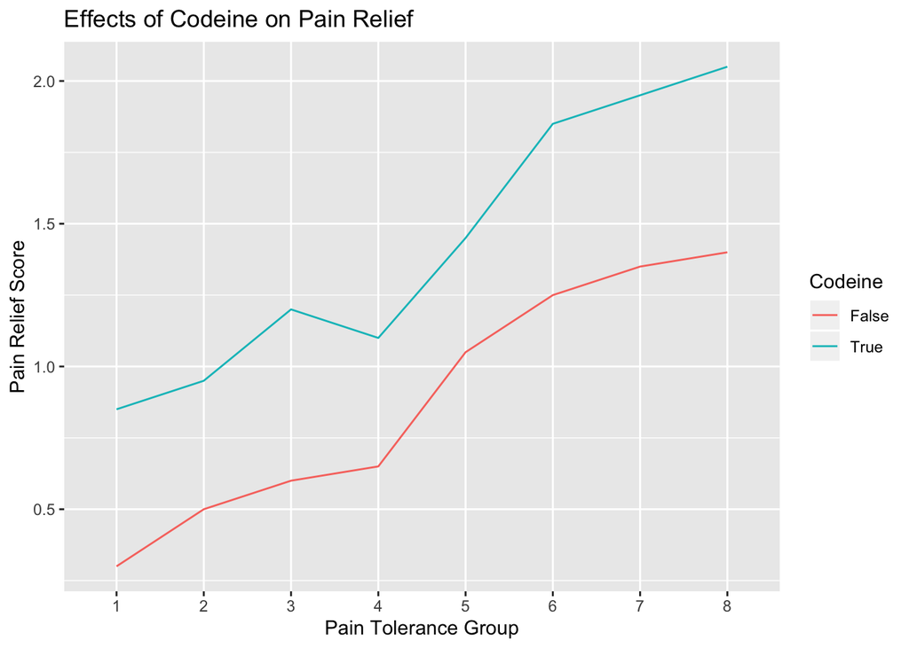

```r
pain.summary <- pain %>%
  group_by(Codeine, PainTolerance) %>%
  summarise(Mean = mean(PainRelief),
            SE = sd(PainRelief)/sqrt(length(PainRelief)))
ggplot(pain.summary, aes(x = PainTolerance, y = Mean, colour = Codeine)) +
  geom_line(aes(group = Codeine)) +
  labs(x = "Pain Tolerance Group", y = "Pain Relief Score") +
  ggtitle("Effects of Codeine on Pain Relief")
```

From this graph we can easily note that taking codeine results in higher pain relief scores than not taking codeine for each pain tolerance group.

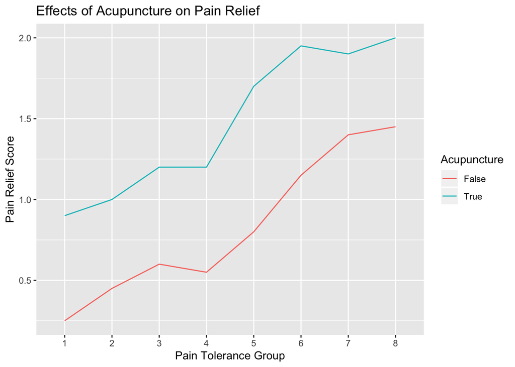

```r
pain.summary2 <- pain %>%
  group_by(Acupuncture, PainTolerance) %>%
  summarise(Mean = mean(PainRelief),
            SE = sd(PainRelief)/sqrt(length(PainRelief)))
ggplot(pain.summary2, aes(x = PainTolerance, y = Mean, colour = Acupuncture)) +
  geom_line(aes(group = Acupuncture)) +
  labs(x = "Pain Tolerance Group", y = "Pain Relief Score") +
  ggtitle("Effects of Acupuncture on Pain Relief")
```

From this graph we can very clearly see that doing acupuncture results in higher pain relief scores than not doing acupuncture for each pain tolerance group.

# Problem 2

## Question 1

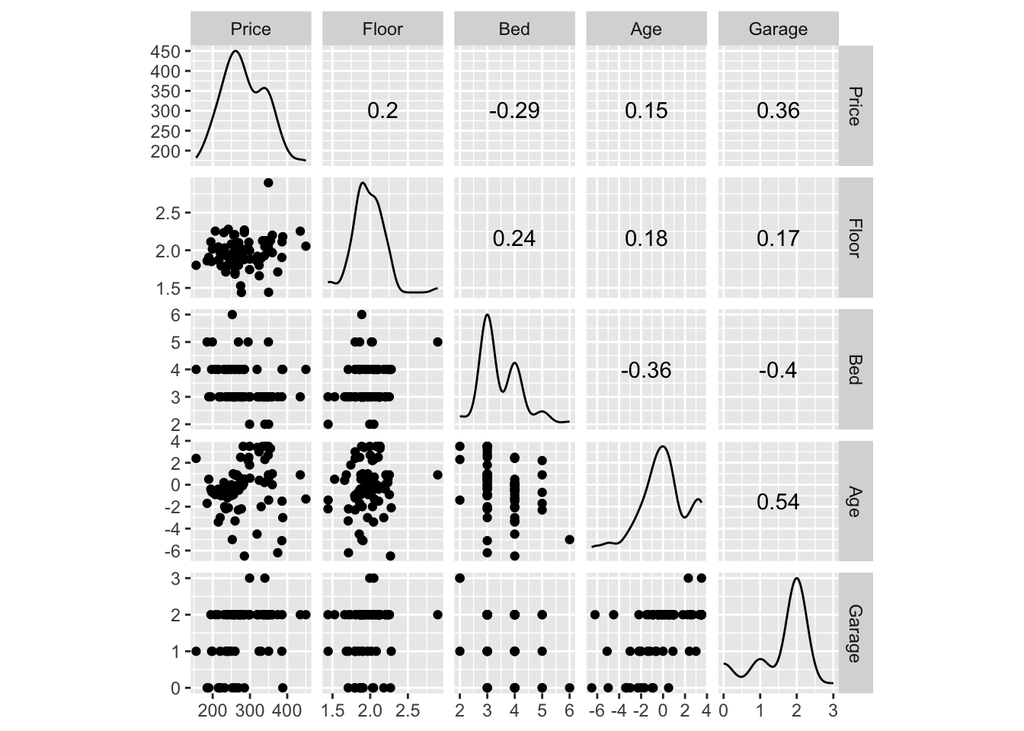

```r
home <- read.csv("homePrices.csv")
ggscatmat(home)
```

From the scatter plot matrix, there do not appear to be any clear or obvious patterns, be it linear or quadratic. The correlation values echo this claim since the strongest correlation is only .54.

## Question 2 and 3

```r
home1 <- lm(Price ~ Floor + Bed + Age + Garage, data = home)
summary(home1)
```

```
##
## Call:
## lm(formula = Price ~ Floor + Bed + Age + Garage, data = home)
##
## Residuals:
##      Min       1Q   Median       3Q      Max
## -121.748  -41.424   -6.231   40.446  157.318
##
## Coefficients:
##             Estimate Std. Error t value Pr(>|t|)
## (Intercept)  194.089     63.438   3.060  0.00313 **
## Floor         69.960     32.941   2.124  0.03717 *
## Bed          -23.275     10.350  -2.249  0.02763 *
## Age           -3.630      3.328  -1.091  0.27907
## Garage        21.638     10.360   2.089  0.04033 *
## ---
## Signif. codes:  0 '***' 0.001 '**' 0.01 '*' 0.05 '.' 0.1 ' ' 1
##
## Residual standard error: 55.17 on 71 degrees of freedom
## Multiple R-squared:  0.2085, Adjusted R-squared:  0.1639
## F-statistic: 4.674 on 4 and 71 DF,  p-value: 0.00209
```

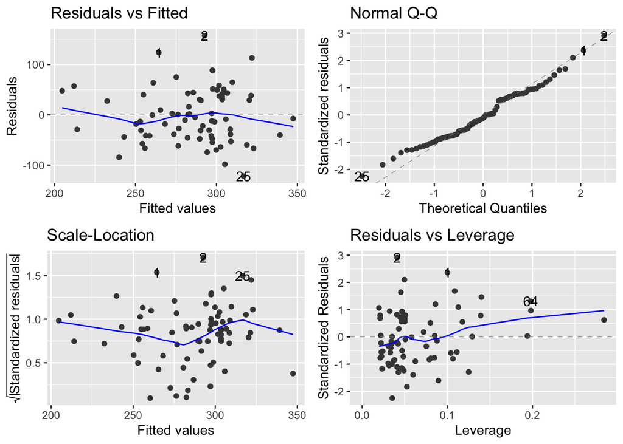

```r
autoplot(home1)
```

In the Residuals vs Fitted plot, the line looks relatively linear but the y-value range spans from -100 to 100 which raises some concern. The normal Q-Q line looks alright except at the bottom where the values seem to taper away from the normality line.

## Question 4

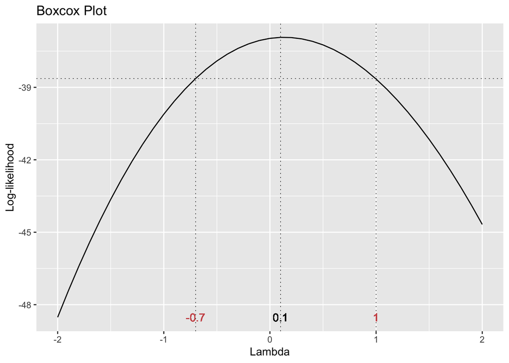

```r
gg_boxcox(home1)
```

The optimal suggested $\lambda$ is 0.1.

## Question 5

```r
home2 <- lm(log(Price) ~ Floor + Bed + Age + Garage, data = home)
summary(home2)
```

```
##
## Call:
## lm(formula = log(Price) ~ Floor + Bed + Age + Garage, data = home)
##
## Residuals:
##      Min       1Q   Median       3Q      Max
## -0.47097 -0.14417 -0.00548  0.14741  0.44932
##
## Coefficients:
##             Estimate Std. Error t value Pr(>|t|)
## (Intercept)  5.33251    0.22197  24.024   <2e-16 ***
## Floor        0.22875    0.11526   1.985   0.0510 .
## Bed         -0.08256    0.03622  -2.280   0.0256 *
## Age         -0.01309    0.01165  -1.124   0.2649
## Garage       0.08540    0.03625   2.356   0.0212 *
## ---
## Signif. codes:  0 '***' 0.001 '**' 0.01 '*' 0.05 '.' 0.1 ' ' 1
##
## Residual standard error: 0.193 on 71 degrees of freedom
## Multiple R-squared:  0.2248, Adjusted R-squared:  0.1812
## F-statistic: 5.148 on 4 and 71 DF,  p-value: 0.001064
```

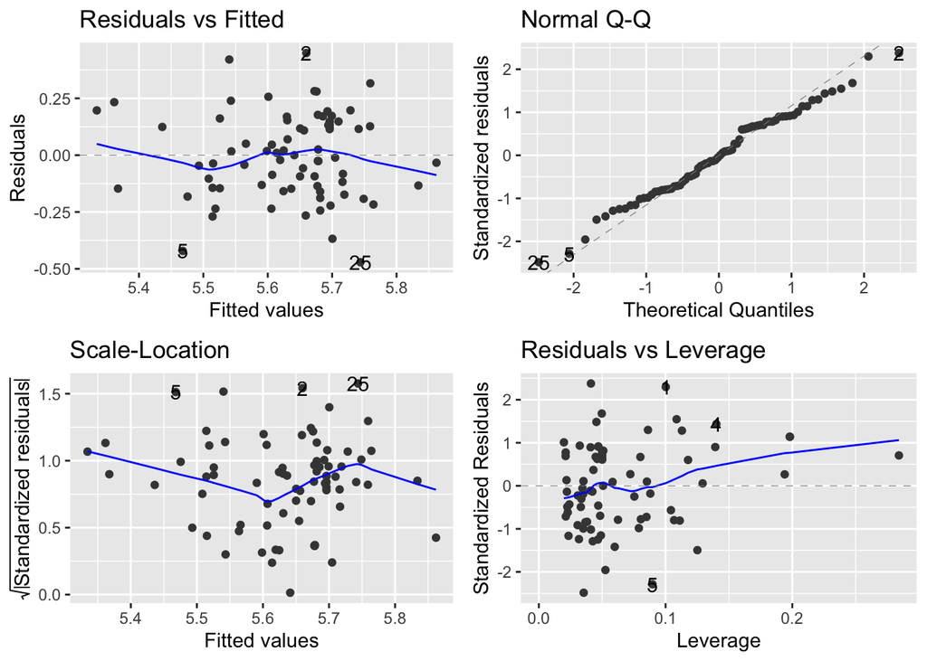

```r
autoplot(home2)
```

## Question 6

Yes, they have been alleviated because the y-value range is now from 0.25 and -0.50. The normal Q-Q plot appears to be normal now, the data points have been pushed closer to the line in the new analysis.